# College Degrees And Income

Hanh Nguyen

12/10/2018

# Overview

Data was obtained from SourceGithub -> tidytuesday -> recent-grads. There are 21 variables and 173 observations in the dataset.

The analysis is based on an article about the relationship between Degrees and Income. The issue we need to keep in mind is that the dataset is from 2010.

Data types for each variable are below.

|  | x |
| --- | --- |
| Rank | integer |
| Major_code | integer |
| Major | character |
| Total | integer |
| Men | integer |
| Women | integer |
| Major_category | character |
| ShareWomen | numeric |
| Sample_size | integer |
| Employed | integer |
| Full_time | integer |
| Part_time | integer |
| Full_time_year_round | integer |
| Unemployed | integer |
| Unemployment_rate | numeric |
| Median | integer |
| P25th | integer |
| P75th | integer |
| College_jobs | integer |
| Non_college_jobs | integer |
| Low_wage_jobs | integer |

Initial Questions:

- What major category is most/least popular?
- Major category difference by gender?
- What major is struggling the most to find a job? What major is easier to find a job?
- Do women struggle more than men to find employment, agnostic of major
- Relationship between earnings, gender gap, and unemployment rate.

## 1. ENROLLMENT DATA

### 1.1 What major category is most/least popular?

Across 16 College Majors, Business is the most popular college major category with highest level of enrollment at 1,302,376.

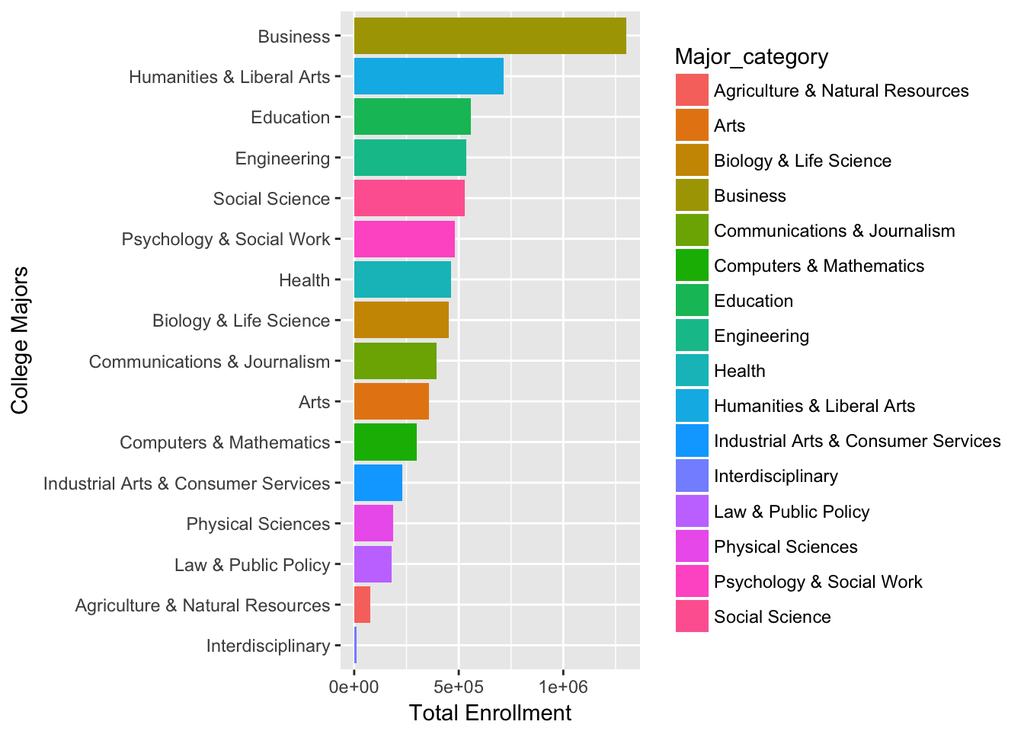

### 1.2 Men/Women are really different in choosing major?

College Majors with the largest gender gaps.

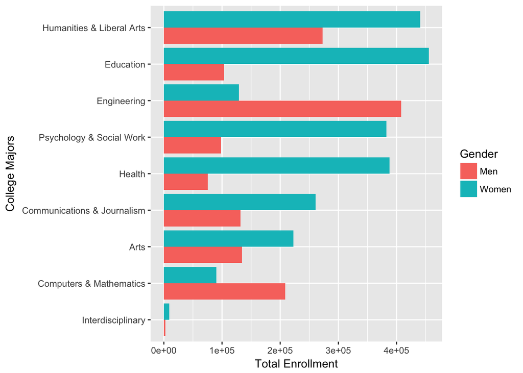

## 2. EMPLOYMENT DATA

### 2.1 Employability by major?

No clear pattern between Major_category and Unemployment_rate.

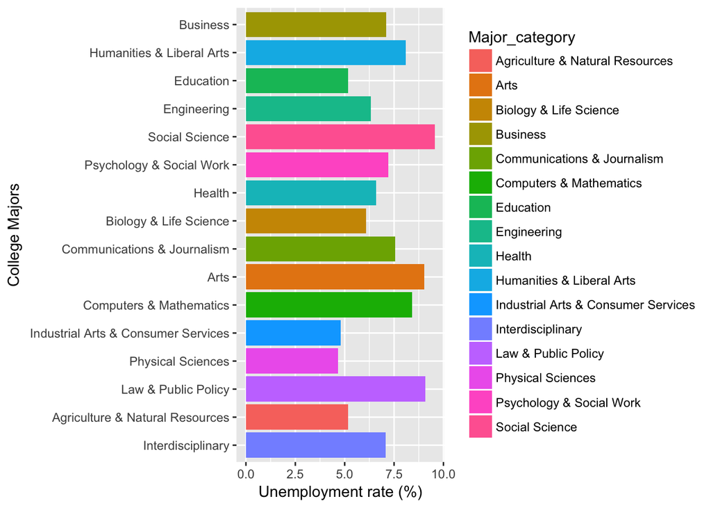

**But don’t assume all college sub majors are the same!**. We dive deeper to see what *college sub majors* students struggle most to find a job and what *college sub majors* where it is easier to find a job.

*Top 5 sub majors, highest rate of unemployment*

Surprisingly, the major with highest rate of unemployment- Nuclear Engineering belongs to Engineering with nearly 20% unemployed.

| Major_category | Major | Total | Unemployment_rate |
| --- | --- | --- | --- |
| Engineering | NUCLEAR ENGINEERING | 2573 | 0.1772264 |
| Law & Public Policy | PUBLIC ADMINISTRATION | 5629 | 0.1594906 |
| Computers & Mathematics | COMPUTER NETWORKING AND TELECOMMUNICATIONS | 7613 | 0.1518498 |
| Psychology & Social Work | CLINICAL PSYCHOLOGY | 2838 | 0.1490482 |
| Law & Public Policy | PUBLIC POLICY | 5978 | 0.1284263 |

*Top 5 sub majors, lowest rate of unemployment*

Bottom line, there are wide differences among majors within a major category. For example, an engineer can still have high chance of being unemployed.

| Major_category | Major | Total | Unemployment_rate |
| --- | --- | --- | --- |
| Computers & Mathematics | MATHEMATICS AND COMPUTER SCIENCE | 609 | 0 |
| Industrial Arts & Consumer Services | MILITARY TECHNOLOGIES | 124 | 0 |
| Biology & Life Science | BOTANY | 1329 | 0 |
| Agriculture & Natural Resources | SOIL SCIENCE | 685 | 0 |
| Education | EDUCATIONAL ADMINISTRATION AND SUPERVISION | 804 | 0 |

### 2.2 Full time job and part time job by college majors, ranked by enrollment

One observation is that the College major with the highest enrollment (Business) also has the highest number in Full time employment.

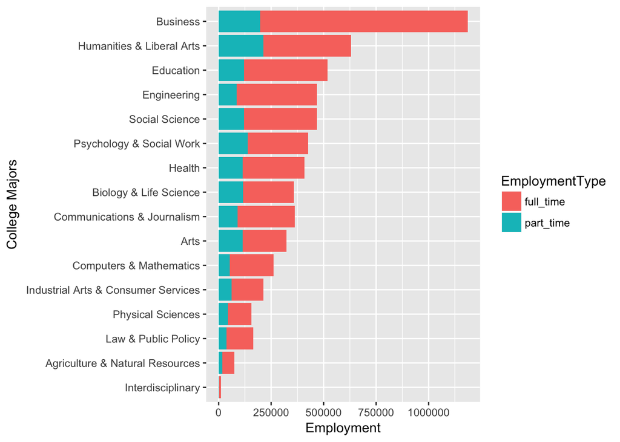

### 2.3 College job and non college job by college majors, ranked by enrollment

But business is also the college major which has the highest percentage of employment in a non-college job (that means a job that doesn’t require that degree).

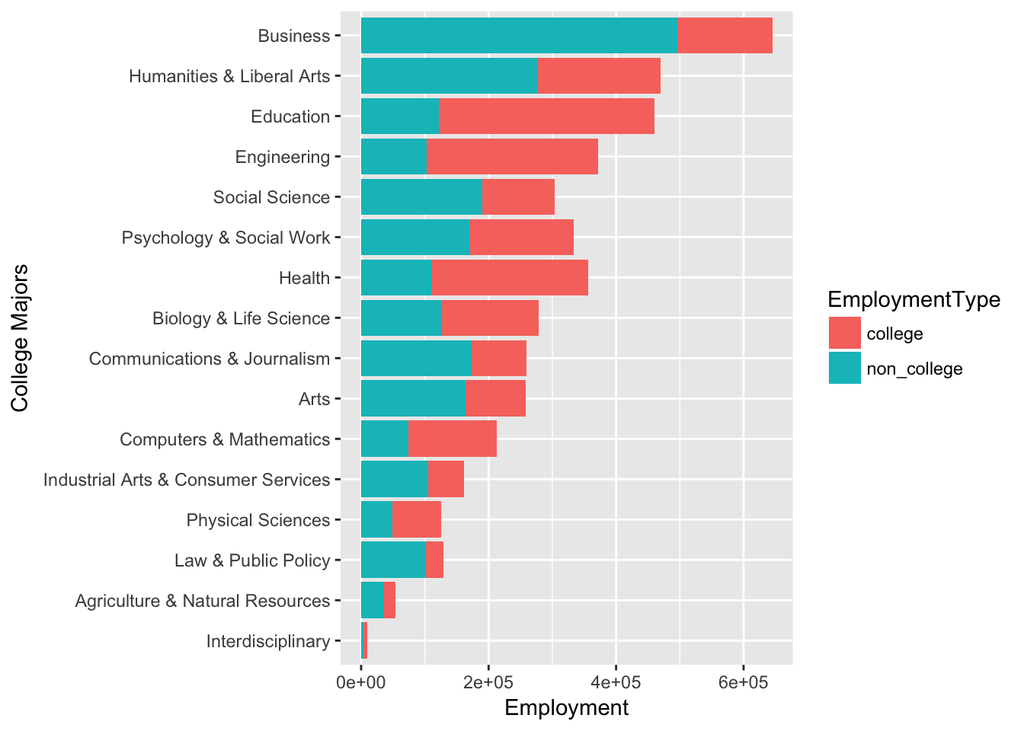

### 2.4 Unemployment rate by gender and Major

- Male dominated sub-majors: sub majors that have percentage of Women signing up less than 50%
- Female dominated sub-majors: sub majors that have percentage of Women signing up more than 50%

Both graphs exhibit similar pattern. Most male dominated sub-majors tend to have unemployment rate around 4%-8% and then 9-10% (we see a more stacked cluster in those areas and then thinner in other areas). Female dominated sub-majors tend to have unemployment rate from 5-8% and mostly less than 10%.

Because the size of the circle represents the median income, we can see that male-dominated graph has more big circle and the scale of the circle also increases by $10,000 while female-dominated graph has fewer big circle and the scale of the circle also increass by less, just $5,000.

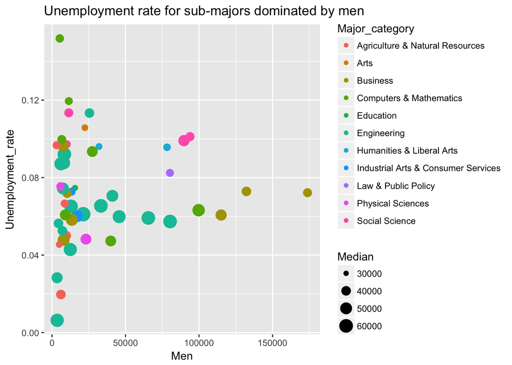

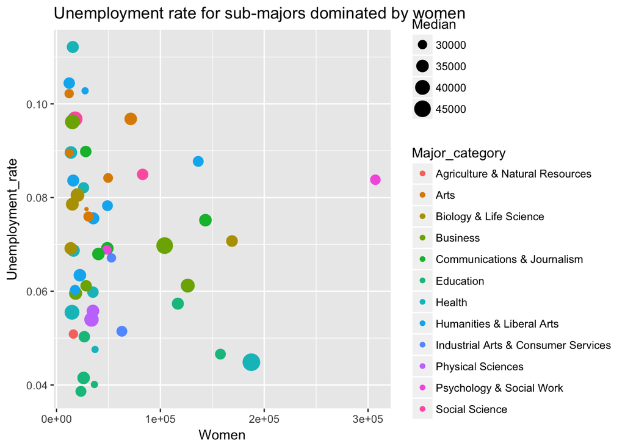

## 3. EARNINGS DATA

## 3.1 Median Income by College Majors

- Engineering has highest Median income.
- Out of all sub-majors, Petroleum Engineering students have the highest Median income after graduation.
- Out of all sub-majors, Library Science student have the lowest Median income after graduation.

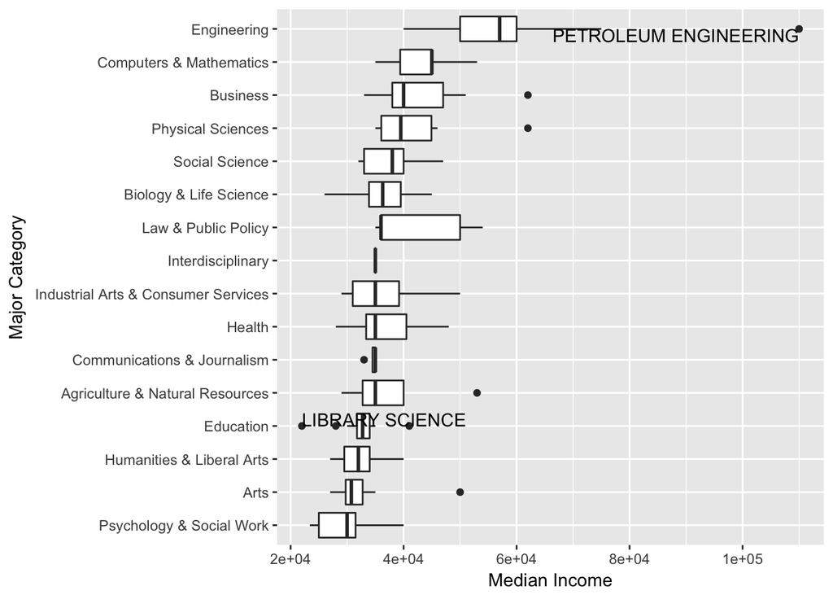

### 3.2 Top 10 Majors with highest earnings, ranked by enrollment

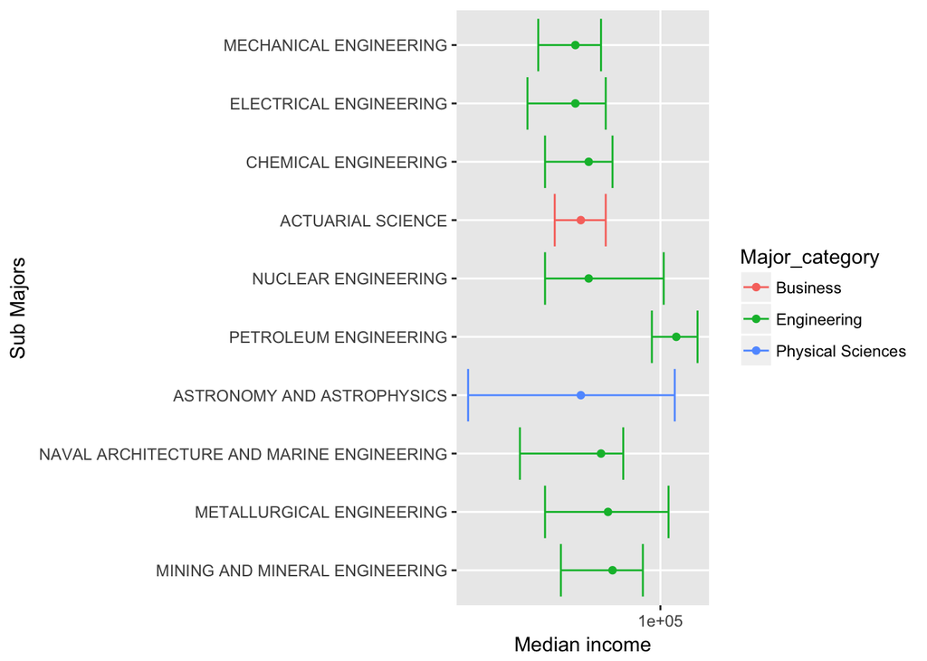

## 4. GENDER AND EARNINGS

### 4.1 First, we build a linear regression model to see how variation in Median Income is explained by multiple independent variables.

```
##
## Call:
## lm(formula = Median ~ ShareWomen + Low_wage_jobs + Full_time +
##     Unemployment_rate, data = degrees)
##
## Residuals:
##    Min     1Q Median     3Q    Max
## -17347  -4859   -826   3407  57566
##
## Coefficients:
##                     Estimate Std. Error t value Pr(>|t|)
## (Intercept)        5.609e+04  2.229e+03  25.163  < 2e-16 ***
## ShareWomen        -2.860e+04  2.979e+03  -9.602  < 2e-16 ***
## Low_wage_jobs     -7.916e-01  2.334e-01  -3.392 0.000867 ***
## Full_time          1.142e-01  3.721e-02   3.068 0.002515 **
## Unemployment_rate -1.465e+04  2.251e+04  -0.651 0.515962
## ---
## Signif. codes:  0 '***' 0.001 '**' 0.01 '*' 0.05 '.' 0.1 ' ' 1
##
## Residual standard error: 8777 on 167 degrees of freedom
##   (1 observation deleted due to missingness)
## Multiple R-squared:  0.4272, Adjusted R-squared:  0.4135
## F-statistic: 31.14 on 4 and 167 DF,  p-value: < 2.2e-16
```

### 4.2 A further look at ShareWomen

As Percentage of women increases, the median income decreases.

*P value is <2 e-16, which means that percentage of women significantly represent median income.* The coefficient is -2.860e+4 which means they are negative related.

It doesn’t necessarily mean that more women in that major, lower earnings for that major. We just witness a negative correlation and that doesn’t indicate a causal relationship. There are a lot of other factors involved.

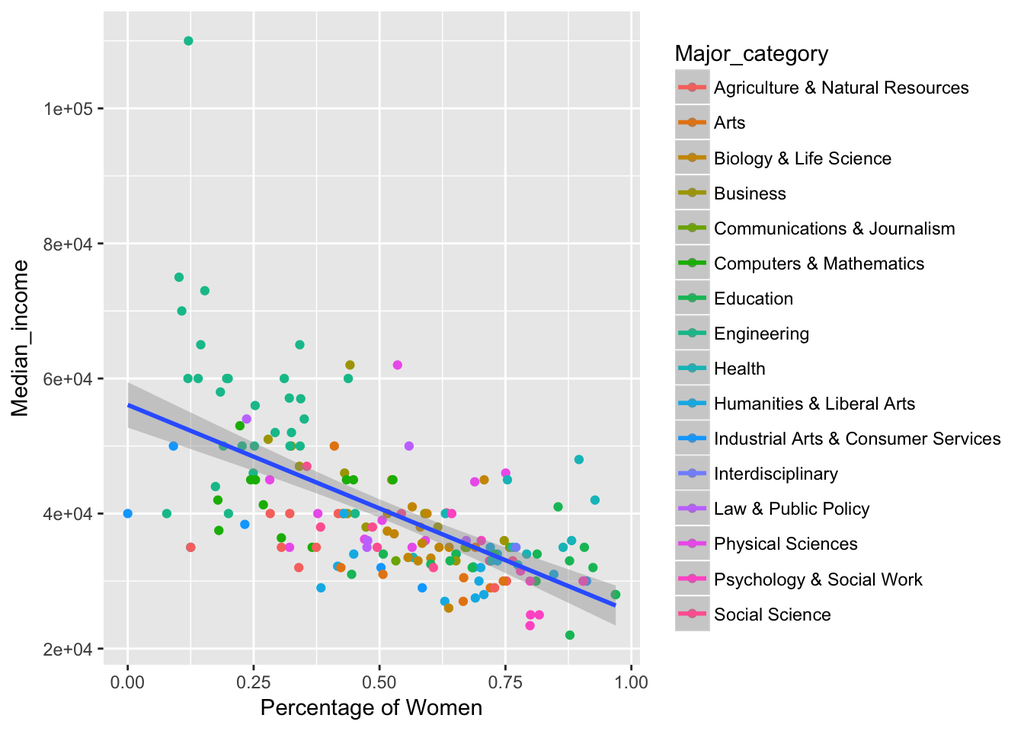

### 4.3 Gender gap earnings, break down by college majors

What we see in this interesting graph is within a major category, how male-dominated major is paid compared to female dominated major? It can be seen that it’s not always male-dominated major is paid higher than female-dominated major.

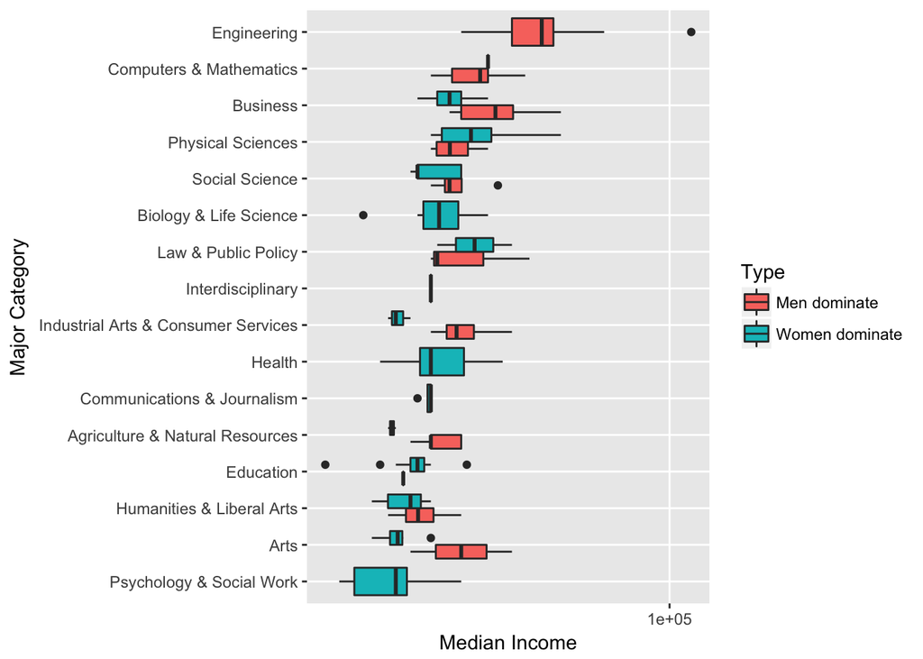

### 4.4 A further look at unemployment rate

Unemployment rate does not significantly represent median income

- P value is 0.5 which is much larger than 0.05 level.
- The coefficient is -1.465e+4.

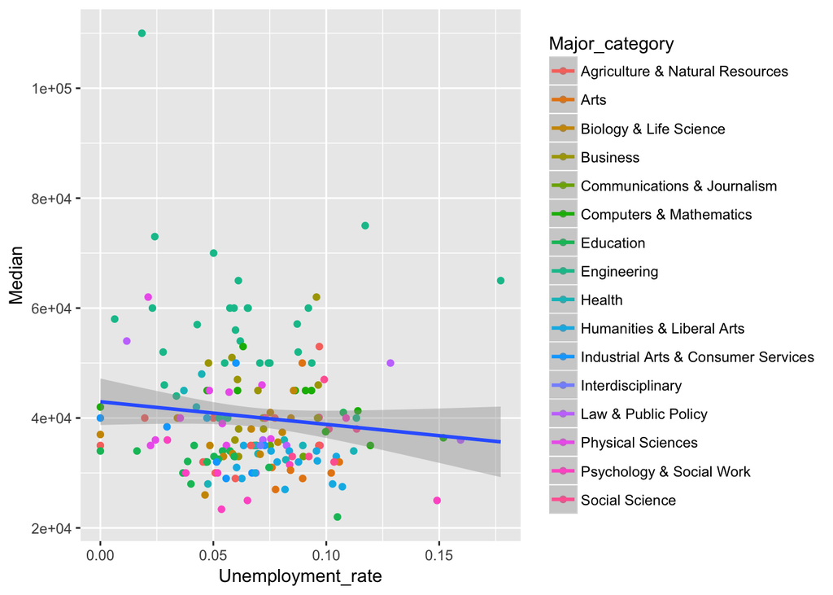